# L’immigration et sa place dans la population tessinoise

Chiara Coppa

5/6/2022

## Choix de la thématique

Pour réaliser le graphique du troisième travail pratique avec R et ggplot, j’ai décidé de prendre en considération le nombre de la population résidente permanente et le nombre d’immigrants dans les communes des districts les plus peuplés du canton Tessin (Rivera, Bellinzona, Locarno, Lugano et Mendrisio).

Plus précisément, selon la définition du 2010 de l’Office fédérale de la Statistique suisse (OFS), le nombre de la population résidente permanente comprend “les Suisses ayant leur domicile principal en Suisse et les étrangers au bénéfice d’une autorisation de résidence d’une durée minimale de 12 mois ou séjournant en Suisse depuis au moins 12 mois”. Au contraire, le nombre d’immigrants fait référence au nombre de personnes qui se sont déplacées de l’étranger vers la Suisse, mais aussi aux personnes qui ont changé leurs statuts de population non-permanente à permanente.

La période que j’ai considérée est celle des années 2012-2014-2015-2016-2018-2020, qui passent de deux en deux (afin de ne pas avoir trop de graphiques) sauf pour l’année 2015, car elle est liée à la crise migratoire du 2015. La crise migratoire s’est produite à cause des conflits civils dans le pays de la Syrie qui a généré une forte émigration du pays, surtout vers les pays européens. Le 2015 a été l’année avec le flux le plus importante de migration (plus d’un million de personnes arrivant dans l’espace Schengen) (Wikipédia, 2022). Le 2015 peut donc montrer si la crise migratoire a impacté aussi la Suisse.

### Est-ce qu’un graphique peut ajouter une plus-value ? Ou est-ce qu’un simple chiffre pourrait éventuellement suffire ?

Il est certainement intéressant de représenter les données à l’aide d’un graphique pour mieux les visualiser (la compréhension à travers un graphique par rapport à un tableau plein de chiffres est plus directe) et comprendre à partir de ça la fonction de l’immigration dans la croissance démographique suisse. L’utilisation des graphiques est donc plus efficace.

### Qu’est-ce que le graphique veut montrer ? Quelle est la question à laquelle le graphique doit répondre ?

Ce que je veux représenter à travers le graphique est l’implication de l’immigration au sein de la population des communes des districts de Rivera, Bellinzona, Locarno, Lugano et Mendrisio du canton Tessin, et voir s’il y a des différences entre les années ou si la relation, dans la période considérée, est la même.

Il permettra de :

- reconnaître la relation entre la population permanente et l’apport de l’immigration pour les communes des différents districts du canton Tessin, cités précédemment,
- savoir si la relation entre les deux variables est changée au cours des dernières années.

## Introduction

Avant de commencer, il faut activer les extensions ggplot2 et tidyverse pour la suite du travail, à travers la commande “library”. Si elles ne se trouvent pas encore dans les extensions de R, il faut utiliser la commande “install.packages” pour les télécharger. Voici la commande (pour installer les extensions faut enlever “#”):

```r
# install.packages("ggplot2")
# install.packages("tidyverse")

library(ggplot2)
library(tidyverse)
```

## Chargement des données

Tout d’abord, j’ai téléchargé depuis STAT-TAB (la banque de données interactive de l’OFS https://www.pxweb.bfs.admin.ch/pxweb/fr/) les données suivantes :

- le nombre de la population résidente permanente,
- le nombre d’immigrés de l’étranger,

les deux pour les années 2012-2014-2015-2016-2018-2020 pour toutes les communes des districts de Rivera, Bellinzona, Locarno, Lugano et Mendrisio du canton Tessin.

Après les avoir téléchargées, je les ai légèrement modifiées dans Excel (pour un tableau en format long) et je les ai copiées-collées dans un éditeur de texte (moi, j’ai utilisé SublimeText) pour les exporter en tsv (avec les données séparées uniquement par des tabulateurs).

Ensuite, j’ai utilisé la commande read.delim(““) qui permet d’ouvrir dans R les fichiers tsv. Je donne aussi un nom au tableau (t) pour qu’il s’enregistre dans l’environnement.

Les commandes suivantes montrent la commande pour lire les données et les sauver dans l’environnement.

```r
t = read.delim("tableau_donnees.tsv")
```

## Réalisation du graphique

Pour réaliser le graphique, j’ai utilisé la commande “ggplot” de la librairie que nous avons téléchargé au début. Les commandes de base sont les suivantes :

```r
p = ggplot(data = t,
           mapping = aes(x = Immigrants , y = Pop_residente))
```

J’ai donné d’abord un nom au graphique de base : p. Après j’ai utilisé la commande “ggplot” dans laquelle j’ai mis les données auxquelles le graphique doit se référer (indiqué par “data = t”, où t est le nom du tableau qu’on a téléchargé), ensuite l’argument mapping = aes() permet de définir les variables pour les axes x et y du graphique.

Ensuite, j’ai défini la typologie du graphique que je voulais produire. Pour cela, j’ai utilisé la commande geom_point, qui crée un graphique en nuage de points. À l’intérieur des parenthèses, j’ai défini un alpha qui représente la transparence des points dans le graphique. L’argument mapping = aes (color = …) se combine avec la première définition du mapping dans ggpolt et distingue les couleurs des points dans le graphique (qui représentent les communes) en fonction des Districts dans lesquels elles se trouvent.

Pour améliorer encore plus le résultat, j’ai modifié les échelles du graphique selon une échelle logarithmique (grâce à scale_x_log10 et scale_y_log10). En plus, j’ai changé le format des valeurs de l’axe y en utilisant des valeurs en notation scientifique.

Au graphique, j’ai ajouté une ligne de tendance avec la fonction geom_smooth dans laquelle j’ai défini sa couleur (color = ), sa taille (size = ) et la méthode dans laquelle elle est définie (dans mon cas, la méthode est loess qui combine plusieurs régressions pour trouver la meilleure).

Ensuite, avec la commande labs() j’ai défini tous les titres et les étiquettes des axes.

Enfin, j’ai décidé de diviser mon graphique en plusieurs graphiques (petits multiples) en ajoutant à la commande la fonction facet_wrap dans laquelle j’ai fixé la variable pour diviser le graphique en petits multiples. Dans mon cas, j’ai divisé le graphique selon la variable “Annee” qui m’as permis de créer six différentes graphiques selon les années considérées.

Pour combiner chaque élément du graphique, j’ai utilisé le signe “+” qui lie ensemble les caractéristiques que je lui ai données.

Si on veut exporter le graphique en pdf on peut ajouter la commande pdf() avec le nom du fichier qu’on va créer et ses dimensions. La fonction dev.off() communique la fin des éléments à inclure dans le fichier pdf.

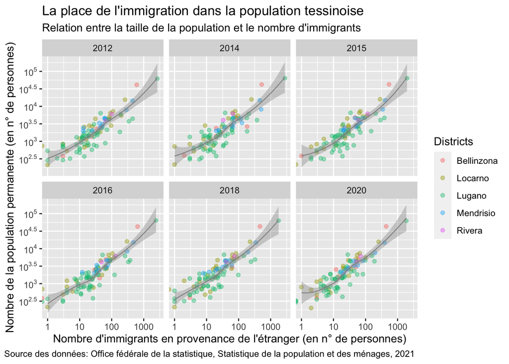

```r
# pdf(file= "Chiara_Coppa_graphique_petits_multiples.pdf", width = 13, height = 8.5)

library(scales) # Pour accéder aux fonctions de transformations du format des valeurs des axes

p + geom_point(alpha = 0.4, mapping = aes(color = Districts)) +
  scale_x_log10()+
  scale_y_log10(breaks = trans_breaks("log10", function(x) 10^x),
              labels = trans_format("log10", math_format(10^.x))) +  # pour changer le format des valeurs des axes

  geom_smooth(method = "loess", color = '#909090', size = 0.4)+
    labs(x = "Nombre d'immigrants en provenance de l'étranger (en n° de personnes)", y = "Nombre de la population permanente (en n° de personnes)",
         title = "La place de l'immigration dans la population tessinoise",
         subtitle = "Relation entre la taille de la population et le nombre d'immigrants",
         caption = "Source des données: Office fédérale de la statistique, Statistique de la population et des ménages, 2021 ") + facet_wrap(~Annee)
```

```r
# dev.off()
```

## Analyse de la corrélation

À travers le test de la corrélation de Pearson (cor.test()), j’ai évalué la corrélation qu’il y a entre les deux variables (même si c’est déjà visible sur le graphique une forte liaison).

```r
cor.test(x = t$Pop_residente, y= t$Immigrants)
```

```
##
##  Pearson's product-moment correlation
##
## data:  t$Pop_residente and t$Immigrants
## t = 48.438, df = 538, p-value < 2.2e-16
## alternative hypothesis: true correlation is not equal to 0
## 95 percent confidence interval:
##  0.8848885 0.9165503
## sample estimates:
##       cor
## 0.9019242
```

Le test donne une valeur de 0.90 (90%) ce qui relève une forte corrélation entre les deux variables. Cette corrélation est aussi **significative** parce que la valeur p (p-value < 2.2e-16) est beaucoup plus petite que la valeur alpha que j’ai fixé à 0.05 (5%).

## Analyse des graphiques

Les six graphiques que j’ai obtenus sont assez similaires entre eux.

- La relation entre la population permanente et l’apport de l’immigration pour les communes des différents districts du canton Tessin est assez considérable.
- La relation entre les deux variables au cours des années n’a pas subi des changements importants.

Les graphiques mettent en évidence le constat suivant : **les communes avec plus de population sont aussi ceux qui ont un afflux majeur de personnes dû à l’immigration**.

Cela est dû à l’attractivité des villes plus peuplées. Ces villes ont, en effet, une offre majeure en services, pour la présence de structures sanitaires, pour la formation éducative et professionnelle, des lieux de détente, des commerces, etc. Ces caractéristiques rendent plus attractive la ville en favorisant l’immigration.

Par exemple, le “point vert” qui se trouve en haute à droite est Lugano. Cette ville est une des villes les plus attrayantes du canton Tessin. Elle possède une qualité de vie élevée avec une multitude de services et de possibilités. En plus, la proximité avec l’Italie favorise l’échange de personnes. C’est grâce à cette offre et à son positionnement stratégique que la ville possède un apport de personnes par l’immigration qui est assez importante. La présence de communautés de migrants d’un certain pays, d’une certaine ethnie, religion, etc. favorise encore plus l’installation d’étrangers, parce qu’ils trouvent des personnes avec les mêmes traditions, les mêmes cultures et les mêmes habitudes. L’installation dans les centres-villes permet d’avoir des commerces plus variés qui facilitent les communautés à trouver les produits typiques de leur pays et de se sentir plus à l’aise en ville.

Au contraire, les villes/villages moins habitées accueillent moins d’immigrants parce qu’ils offrent moins de possibilités aux gens qui arrivent de l’étranger (plus de villages ruraux moins attractives).

La crise migratoire du 2015 n’a pas affecté la démographie des districts. Il n’y a donc pas des différences substantielles avec les autres années.

La dernière chose qu’on remarque en regardant les graphiques est que, le plus souvent, les points du district de Lugano (vert), se trouvent au-dessous de la ligne de régression (qui désigne une présence majeure d’immigration) par rapport aux communes du district de Locarno qui se trouvent davantage au-dessus de la ligne (qui montre une présence moins puissante de l’immigration).

## Conclusion

Les graphiques m’ont permis de recueillir les informations sur la place de l’immigration dans les communes des districts de Rivera, Bellinzona, Locarno, Lugano et Mendrisio du canton Tessin, en montrant que les communes les plus peuplées sont ceux qui accueillent le plus les personnes venant de l’étranger. Cette représentation est toutefois limitée, surtout au niveau de l’évolution au cours des années. Il aurait été préférable d’avoir les données d’années plus anciennes pour mieux comprendre l’évolution dans le temps de la relation entre les deux variables. Il aurait également pu être intéressant d’avoir les données des années du Covid-19 pour observer si la migration a été ralentie par la pandémie.

## Bibliographie

- Crise migratoire en Europe (2022). Dans Wikipédia. Repéré à [https://fr.wikipedia.org/wiki/Crise_migratoire_en_Europe].